# test_EvadeGANxz

```python
%autoreload
```

### **Plot the TPR and training metrics**

```python
%autoreload
plot_TPR_metrics(TPR_train, TPR_test, avg_diff_train, avg_diff_test,
                 d_metrics, gan_metrics)
```

[figure not shown]

### **How well does the discriminator approximate the target model?**

The discriminator is evaluated on all the samples that are **correctly classified** by the **target model (True Positives & True Negatives)**.

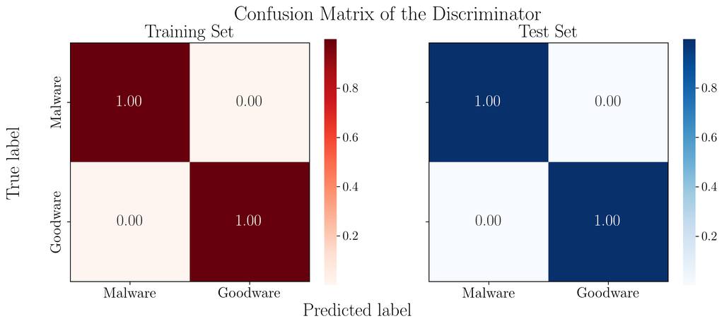

```python
%autoreload
# Evaluate discriminatior (how well does it approximate the target model)

Y_true_train = np.concatenate((MAL_LABEL * ones(X_mal_train.shape[0]),
                              GOOD_LABEL * ones(X_good_train.shape[0])))
Y_pred_train = \
    np.concatenate(
        (binarise(evadeGAN.discriminator.predict(X_mal_train), bin_threshold),
        binarise(evadeGAN.discriminator.predict(X_good_train), bin_threshold))
    )

Y_true_test = np.concatenate((MAL_LABEL * ones(X_mal_test.shape[0]),
                              GOOD_LABEL * ones(X_good_test.shape[0])))
Y_pred_test = \
    np.concatenate(
        (binarise(evadeGAN.discriminator.predict(X_mal_test), bin_threshold),
         binarise(evadeGAN.discriminator.predict(X_good_test), bin_threshold))
    )

plot_confusion_matrix(Y_true_train, Y_pred_train, Y_true_test, Y_pred_test,
                      title="Confusion Matrix of the Discriminator")
```

### **Best Generator**

```python
generator = load_model(best_G_path)
```

```
WARNING:tensorflow:No training configuration found in the save file, so the model was *not* compiled. Compile it manually.
```

```python
%autoreload
pd.options.display.max_rows = 1000
```

### **Generate AEs**

**A. Many X's and many Z's**

```python
# Matrix to array
x_good_train = np.asarray(X_good_train)   # To analyse perturbations
x_mal_train = np.asarray(X_mal_train)     # To analyse perturbations
x_mal_test = np.asarray(X_mal_test)       # To generate AEs

z = np.random.uniform(0.0, 1.0, size=[X_mal_test.shape[0], z_dim])

x_adv = generator.predict([X_mal_test, z])
x_adv = binarise(x_adv).numpy()           # Binary AE
perturbs = x_adv - x_mal_test             # Delta = x' - x
```

**B. One X and many Z's (does changing z produce diverse AEs?)**

```python
N = 100
x_one = np.repeat(X_mal_test[0], N, axis=0)

z_one = np.random.uniform(0.0, 1.0, size=[N, z_dim])

x_adv_one = generator.predict([x_one, z_one])
x_adv_one = binarise(x_adv_one).numpy()         # Binary AE
perturbs_one = x_adv_one - x_one                # Delta = x' - x
```

#### Double-Check Evasion (Misclassification)

**A. Many X's and many Z's**

```python
y_adv = model.predict(x_adv)
print(f'{np.count_nonzero(y_adv)} AEs classified as malware.') # Evasive AEs?
```

```
0 AEs classified as malware.
```

**B. One X and many Z's (does changing z produce diverse AEs?)**

```python
y_adv_one = model.predict(x_adv_one)
print(f'{np.count_nonzero(y_adv_one)} AEs classified as malware.') # Evasive AEs?
```

```
0 AEs classified as malware.
```

## **Analyse Pertubations**

### **1. Unique pertubations**

**A. Many X's and many Z's**

```python
df_perturbs = pd.DataFrame(perturbs)
unique_perturbs = df_perturbs.drop_duplicates()
print(f"{'Numer of AEs:':<20} {X_mal_test.shape[0]}")
print(f"{'Unique Pertubations:':<20} {unique_perturbs.shape[0]}  "
      f"({100*unique_perturbs.shape[0]/X_mal_test.shape[0]:.2f}%)")
```

```
Numer of AEs:        3451
Unique Pertubations: 752  (21.79%)
```

```python
df_perturbs.astype(bool).sum(axis=1).describe()
```

```
count    3451.000000
mean       11.924949
std         8.292577
min         3.000000
25%         7.000000
50%        10.000000
75%        14.000000
max       135.000000
dtype: float64
```

**B. One X and many Z's (does changing z produce diverse AEs?)**

```python
df_perturbs_one = pd.DataFrame(perturbs_one)
unique_perturbs_one = df_perturbs_one.drop_duplicates()
print(f"{'Numer of AEs:':<20} {x_one.shape[0]}")
print(f"{'Unique Pertubations:':<20} {unique_perturbs_one.shape[0]}  "
      f"({100*unique_perturbs_one.shape[0]/x_one.shape[0]:.2f}%)")
```

```
Numer of AEs:        100
Unique Pertubations: 11  (11.00%)
```

```python
df_perturbs_one.astype(bool).sum(axis=1).describe()
```

```
count    100.00
mean      23.16
std        1.60
min       20.00
25%       23.00
50%       23.00
75%       24.00
max       28.00
dtype: float64
```

### **2. What Features were added in perturbations?**

```python
feature_names = data.get_feature_names()
feature_weights = weights
perturb_count = pd.DataFrame(perturbs).astype(bool).sum(axis=0)         # Feature count in perturbations
mal_test_count = pd.DataFrame(X_mal_test).astype(bool).sum(axis=0)      # Feature count in testing malware
mal_train_count = pd.DataFrame(X_mal_train).astype(bool).sum(axis=0)    # Feature count in training malware
good_train_count = pd.DataFrame(X_good_train).astype(bool).sum(axis=0)  # Feature count in training goodware

df = pd.DataFrame({'FeatureName': feature_names,
                   'FeatureWeight': feature_weights,
                   'malTestCount': mal_test_count,
                   'malTrainCount': mal_train_count,
                   'malTrainFreq': mal_train_count / X_mal_train.shape[0],
                   'goodTrainCount': good_train_count,
                   'goodTrainFreq': good_train_count / X_good_train.shape[0],
                   'PerturbCount': perturb_count})
```

### **2.1. Features sorted by perturbation count (Descending)**

Check their **weights** and **frequencies** in *malware* (**training** and **test** sets) and *goodware*.

```python
df.sort_values(['PerturbCount'], ascending=False).round(5).head(100)   # Top 100
```

|  | FeatureName | FeatureWeight | malTestCount | malTrainCount | malTrainFreq | goodTrainCount | goodTrainFreq | PerturbCount |
| --- | --- | --- | --- | --- | --- | --- | --- | --- |
| 2817 | interesting_calls::Cipher(RSA/None/PKCS1Padding) | -1.09402 | 16 | 68 | 0.00811 | 168 | 0.00206 | 3423 |
| 2872 | urls::10_0_2_2 | -0.51980 | 31 | 69 | 0.00823 | 2283 | 0.02806 | 3416 |
| 3658 | urls::http://admin_appnext_com/ | -1.61378 | 27 | 48 | 0.00572 | 57 | 0.00070 | 3403 |
| 8448 | urls::http://www_startappexchange_com/1_3/trac... | -2.10412 | 98 | 229 | 0.02731 | 147 | 0.00181 | 3349 |
| 6455 | urls::http://my_mobfox_com/request_php | -1.00868 | 11 | 31 | 0.00370 | 925 | 0.01137 | 3136 |
| 2336 | api_permissions::android_permission_AUTHENTICA... | -0.64760 | 9 | 25 | 0.00298 | 1039 | 0.01277 | 2868 |
| 3681 | urls::http://ads_heyzap_com/in_game_api/ads | -0.71247 | 37 | 119 | 0.01419 | 431 | 0.00530 | 2208 |
| 9119 | urls::https://app_adjust_com | -0.77310 | 0 | 1 | 0.00012 | 373 | 0.00458 | 2116 |
| 638 | activities::com_ccx_xm_AdActivity | -0.85428 | 6 | 13 | 0.00155 | 65 | 0.00080 | 1896 |
| 8295 | urls::http://www_jivesoftware_com/xmlns/xmpp/p... | -0.84291 | 30 | 93 | 0.01109 | 561 | 0.00690 | 1471 |
| 381 | activities::cn_jpush_android_ui_PushActivity | -0.52976 | 68 | 140 | 0.01670 | 398 | 0.00489 | 1142 |
| 6149 | urls::http://maps_google_com/maps/api/geocode/... | -0.82607 | 0 | 0 | 0.00000 | 274 | 0.00337 | 1141 |
| 1301 | activities::com_qbiki_seattleclouds_SettingsAc... | -0.87384 | 5 | 11 | 0.00131 | 417 | 0.00513 | 982 |
| 53 | activities::_AndromoDashboardActivity | -0.91863 | 0 | 0 | 0.00000 | 544 | 0.00669 | 950 |
| 6497 | urls::http://ns_adobe_com/exif/1_0/aux/ | -0.55927 | 0 | 0 | 0.00000 | 325 | 0.00399 | 934 |
| 2604 | intents::android_intent_action_SEND_MULTIPLE | -0.90028 | 2 | 15 | 0.00179 | 623 | 0.00766 | 844 |
| 8881 | urls::https://api_parse_com/1/ | -1.00823 | 1 | 8 | 0.00095 | 352 | 0.00433 | 834 |
| 9203 | urls::https://device-api_urbanairship_com/ | -0.61931 | 0 | 5 | 0.00060 | 1175 | 0.01444 | 818 |
| 354 | activities::android_support_v7_widget_TestActi... | -0.72467 | 8 | 32 | 0.00382 | 1019 | 0.01252 | 595 |
| 8249 | urls::http://www_google_com/loc/json | -0.44640 | 9 | 42 | 0.00501 | 85 | 0.00104 | 595 |
| 8353 | urls::http://www_ngs_ac_uk/tools/jcepolicyfiles | -0.50061 | 0 | 0 | 0.00000 | 522 | 0.00642 | 422 |
| 2476 | app_permissions::name='com_android_browser_per... | -0.41756 | 50 | 113 | 0.01348 | 663 | 0.00815 | 352 |
| 2574 | intents::android_intent_action_HEADSET_PLUG | -0.74351 | 3 | 5 | 0.00060 | 610 | 0.00750 | 326 |
| 6793 | urls::http://play_google_com/store/apps/details | -1.07395 | 33 | 97 | 0.01157 | 3447 | 0.04237 | 320 |
| 8 | activities::Applications | -0.23285 | 40 | 107 | 0.01276 | 98 | 0.00120 | 264 |
| 4582 | urls::http://custom_com | -0.00000 | 0 | 0 | 0.00000 | 173 | 0.00213 | 254 |
| 9471 | urls::https://onesignal_com/api/v1/ | -0.04089 | 0 | 2 | 0.00024 | 265 | 0.00326 | 253 |
| 7470 | urls::http://test_urbanairship_com | -0.58173 | 1 | 6 | 0.00072 | 568 | 0.00698 | 242 |
| 517 | activities::com_appmk_magazine_main_MagazineAc... | -0.00000 | 0 | 0 | 0.00000 | 173 | 0.00213 | 230 |
| 2824 | interesting_calls::Cipher(code) | -0.32631 | 0 | 0 | 0.00000 | 202 | 0.00248 | 219 |

[output cut: 70 more lines]

### **2.2. Features sorted by weights (Ascending)**

```python
df.sort_values(['FeatureWeight'], ascending=True).round(5).head(100)
```

|  | FeatureName | FeatureWeight | malTestCount | malTrainCount | malTrainFreq | goodTrainCount | goodTrainFreq | PerturbCount |
| --- | --- | --- | --- | --- | --- | --- | --- | --- |
| 6831 | urls::http://portre_yemonisoni_com/mcla | -2.47986 | 6 | 3 | 0.00036 | 377 | 0.00463 | 45 |
| 8448 | urls::http://www_startappexchange_com/1_3/trac... | -2.10412 | 98 | 229 | 0.02731 | 147 | 0.00181 | 3349 |
| 1328 | activities::com_revmob_FullscreenActivity | -1.77385 | 11 | 28 | 0.00334 | 25 | 0.00031 | 0 |
| 6828 | urls::http://pms_mb_qq_com/rsp204 | -1.66521 | 2 | 10 | 0.00119 | 12 | 0.00015 | 0 |
| 3658 | urls::http://admin_appnext_com/ | -1.61378 | 27 | 48 | 0.00572 | 57 | 0.00070 | 3403 |
| 8236 | urls::http://www_google-analytics_com/collect | -1.57233 | 585 | 1316 | 0.15695 | 25337 | 0.31142 | 4 |
| 3694 | urls::http://ads_mobilecore_com/?package= | -1.44954 | 64 | 154 | 0.01837 | 872 | 0.01072 | 0 |
| 2806 | interesting_calls::Cipher(Lorg/chromium/base/O... | -1.41060 | 2 | 2 | 0.00024 | 329 | 0.00404 | 0 |
| 5683 | urls::http://i_ytimg_com/vi/ | -1.40111 | 228 | 442 | 0.05271 | 1026 | 0.01261 | 0 |
| 9744 | urls::https://sites_google_com/site/gamegripper | -1.32769 | 8 | 40 | 0.00477 | 3 | 0.00004 | 0 |
| 307 | activities::_ads_vast_VideoAdsLoaderActivity | -1.29557 | 31 | 71 | 0.00847 | 18 | 0.00022 | 0 |
| 6546 | urls::http://opds-spec_org/2010/catalog | -1.28479 | 1 | 28 | 0.00334 | 40 | 0.00049 | 0 |
| 8562 | urls::http://www_youtube_com/embed/ | -1.25572 | 227 | 447 | 0.05331 | 1128 | 0.01386 | 0 |
| 6314 | urls::http://mobads_baidu_com/cpro/ui/mads_php... | -1.22401 | 6 | 3 | 0.00036 | 2 | 0.00002 | 0 |
| 5924 | urls::http://loc_map_baidu_com/tcu_php | -1.21986 | 50 | 129 | 0.01538 | 366 | 0.00450 | 0 |
| 8450 | urls::http://www_startappexchange_com/tracking... | -1.21676 | 139 | 327 | 0.03900 | 220 | 0.00270 | 0 |
| 2354 | api_permissions::android_permission_READ_LOGS | -1.19574 | 1704 | 4397 | 0.52439 | 15540 | 0.19101 | 0 |
| 5698 | urls::http://iframe_ip138_com/ic_asp | -1.15134 | 8 | 13 | 0.00155 | 28 | 0.00034 | 0 |
| 175 | activities::_MAME4all | -1.13175 | 31 | 110 | 0.01312 | 5 | 0.00006 | 0 |
| 8774 | urls::https://ad_mail_ru/mobile/ | -1.11570 | 86 | 185 | 0.02206 | 74 | 0.00091 | 0 |
| 197 | activities::_MonacaSScreenActivity | -1.10277 | 0 | 8 | 0.00095 | 1 | 0.00001 | 0 |
| 4637 | urls::http://data_altbeacon_org/android-distan... | -1.09506 | 41 | 94 | 0.01121 | 371 | 0.00456 | 0 |
| 2817 | interesting_calls::Cipher(RSA/None/PKCS1Padding) | -1.09402 | 16 | 68 | 0.00811 | 168 | 0.00206 | 3423 |
| 7363 | urls::http://strategy_beacon_qq_com/analytics/... | -1.09165 | 2 | 7 | 0.00083 | 7 | 0.00009 | 0 |
| 2141 | activities::org_jufh_xmvo_woeiwej_Suzi | -1.09027 | 1 | 5 | 0.00060 | 2 | 0.00002 | 0 |
| 8560 | urls::http://www_youtube_com | -1.08235 | 2 | 6 | 0.00072 | 929 | 0.01142 | 118 |
| 9912 | urls::https://www_googleapis_com/oauth2/v1/certs | -1.07974 | 3 | 5 | 0.00060 | 382 | 0.00470 | 140 |
| 6793 | urls::http://play_google_com/store/apps/details | -1.07395 | 33 | 97 | 0.01157 | 3447 | 0.04237 | 320 |
| 4148 | urls::http://api_w_inmobi_com/showad/v2 | -1.04519 | 25 | 30 | 0.00358 | 69 | 0.00085 | 0 |
| 9804 | urls::https://twitter_com/%s/status/%d | -1.04500 | 0 | 0 | 0.00000 | 386 | 0.00474 | 0 |

[output cut: 70 more lines]